# **KSU paired amplicons: *Darksidea***

Distribution and diversity of *Darksidea sp.

Kelli Feeser

2023-11-28

# Data Overview

### OTU tables

Taxonomy assigned using SINTAX algorithm (USEARCH v11)  
Reference database: most current UNITE UNITE USEARCH/UTAX release for eukaryotes

- version no 9.0, release date 2023-07-18
- taxon group: All eukaryotes
- location: https://dx.doi.org/10.15156/BIO/2938084
- citation: Abarenkov, Kessy; Zirk, Allan; Piirmann, Timo; Pöhönen, Raivo; Ivanov, Filipp; Nilsson, R. Henrik; Kõljalg, Urmas (2023): UNITE USEARCH/UTAX release for eukaryotes. Version 18.07.2023. UNITE Community. https://doi.org/10.15156/BIO/2938084

All EDGE samples have been excluded  
ITS OTU table rarefied to 10,116 seqs/sample

**Fungal (ITS) Dataset:**

- 6,749 OTUs
- 509 samples
- 731 unique genera detected, inc. *Darksidea*

### Available metadata

Note that numeric metadata has been mean standardized.

*Sampling Variables:*

*Climate Data:*

- **GDD** = growing degree days (determined over 3- and 30-year windows and in 2015)
- **ppt** = mean annual precipitation (determined over 3- and 30-year windows and in 2015)  
  *Data from PRISM Climate Group 2019 (Oregon State University)

*Edaphic Variables:*

- **ammonium** (NH<sub>4</sub><sup>+</sup>)
- **nitrate** (NO<sub>3</sub><sup>–</sup>)
- **SOM** (via LoI)
- **phosphorous** (total P)
- **pH**
- **soil_moisture** = percentage by weight of water in soil (by sample, Rudgers et al. called this a climate variable)  
  *soils combined within each Grass Host x Site combination

*Plant Traits:*

- **avg_SLA**: specific leaf area
- **avg_SRL**: specific root length
  - Large values of specific leaf area (SLA) and specific root length (SRL) reflect large plant investment in resource acquisition; small values indicate investment in plant tissue longevity
- **herbivory_perc**: average site level damage estimate for herbivory, averaged over all species and individuals at the site; could be used to indicate herbivory pressure at the site level
  - ranges from 1:17

## OTU-level relative abundance

Relative abundance of each OTU were averaged across all samples for this table.

This dataset contains 3 OTUs belonging to genus *Darksidea*.

At the OTU/species-level, all *Darksidea* OTUs were classified as “uncl_Darksidea”.

Mean and sd of *Darksidea* OTUs abundance across all samples:

- OTU5613: 0.019 ± 0.09%
- OTU7431: 0.00017 ± 0.003%
- OTU9749: 0.0087 ± 0.05%
  - Global sum: 0.028%

## Genus-level relative abundance

Relative abundance of each OTU were averaged across all samples for this table.

This dataset contains 3 OTUs belonging to genus *Darksidea*.

At the species-level, all *Darksidea* OTUs were classified as “uncl_Darksidea”.

Across all samples, *Darksidea* had an average relative abundance of 0.028 ± 0.11%.

[output not shown]

[output cut: 721 more lines]

# Occupancy-abundance, OTU-level

## All Grasses

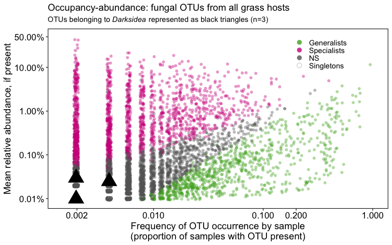

Figure 1: Occupancy-abundance figure overlayed with generalist framework results from OTU down-selection for co-occurrence (top 2.5% of distribution). Plot contains data from all samples and OTUs. I have added in the generalist vs. specialist (GvS) OTU annotations. ‘Generalist’ OTUs have the highest 2.5% of occurrence:abundance distribution, ‘specialists’ are in the lowest lowest 2.5%, ‘NS’ are the non-significant OTUs falling in the middle 95%, ‘singletons’ are OTUs that only appeared in a single sample and thus were excluded from GvS analyses. GvS calculations were run independently for the full dataset (all grass hosts) and for the by-host data. Note both axes are shown on a log scale.

## *Blue grama*

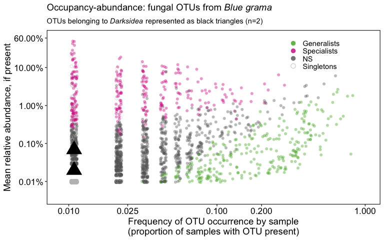

Figure 2: Occupancy-abundance figure overlayed with generalist framework results from OTU down-selection for co-occurrence (top 2.5% of distribution). Plot contains data from all OTUs associated with *Blue grama* hosts. I have added in the generalist vs. specialist (GvS) OTU annotations. ‘Generalist’ OTUs have the highest 2.5% of occurrence:abundance distribution, ‘specialists’ are in the lowest lowest 2.5%, ‘NS’ are the non-significant OTUs falling in the middle 95%, ‘singletons’ are OTUs that only appeared in a single sample and thus were excluded from GvS analyses. GvS calculations were run independently for the full dataset (all grass hosts) and for the by-host data. Note both axes are shown on a log scale.

## *Black grama*

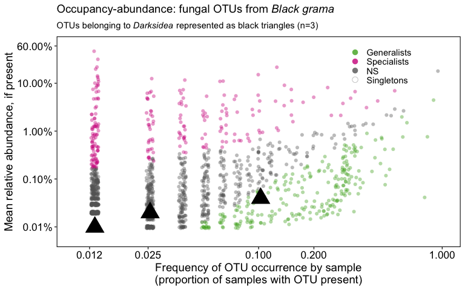

Figure 3: Occupancy-abundance figure overlayed with generalist framework results from OTU down-selection for co-occurrence (top 2.5% of distribution). Plot contains data from all OTUs associated with *Black grama* hosts. I have added in the generalist vs. specialist (GvS) OTU annotations. ‘Generalist’ OTUs have the highest 2.5% of occurrence:abundance distribution, ‘specialists’ are in the lowest lowest 2.5%, ‘NS’ are the non-significant OTUs falling in the middle 95%, ‘singletons’ are OTUs that only appeared in a single sample and thus were excluded from GvS analyses. GvS calculations were run independently for the full dataset (all grass hosts) and for the by-host data. Note both axes are shown on a log scale.

# Distribution of *Darksidea* OTUs

n=3 *Darksidea* OTUs

At the SEV only:

- Of the 2 grasses present at the SEV (*Blue* and *Black grama*),
  - 0 OTUs detected in *Blue* *grama* associated soils
  - 1 / 3 OTUs detected in 11.1% of *Black* *grama* associated soils

Across all sites

By Site

- 23 sites in dataset
- 1 site had all 3 *Darksidea* OTUs detected, with the following mean frequency
  - BLM: 17.4%
- 9 sites had 2 of 3 *Darksidea* OTUs detected, with the following mean frequencies (when present)
  - OTUs `OTU9749` and `OTU5613`
    - CPR: 13.6%
    - FCP: 12.5%
    - FMT: 5.9%
    - HAR: 31.1%
    - HPG: 60%
    - KNZ: 10.2%
    - LBJ: 2.9%
    - RNF: 50%
  - OTUs `OTU7431` and `OTU5613`
    - GMT: 13.6%
- 5 sites had 1 of 3 *Darksidea* OTUs detected, with the following mean frequencies (when present)
  - OTU `OTU9749`
    - CNF: 28.6%
    - DMT: 7.14%
    - KAE: 6.25%
    - SEV: 8.33%
  - OTU `OTU5613`
    - SCP: 20%
- 8 sites had no *Darksidea* OTUs detected (BNP, CAD, GNF, LAR, NWP, ONF, SFA, UHC)

# Metadata variables impacting presence of *Darksidea* OTUs

*Methods*: For discrete metadata factors (e.g., Grass Host, Site), calculating occurrence for *Darksidea* OTUs by factor level and assessing significance of Occurrence ~ Factor via Kruskal-Wallis rank sum test (“KW”). For continuous metadata variables, I have converted the *Darksidea* OTU table to presence/absence, and assessed significance via a one-way ANOVA. All statistical tests in this section are single-term only. All continuous metadata variables have been mean standardized with the exceptions of elevation, latitude, and longitude.

- Furthermore I calculated the variance explained by each variable
  - Kruskal-Wallis: $\eta^2$ (effect size, essentially equivalent to $R^2$) using $\eta$$p^2 = (F * dfn)/(F * dfn + dfd)$, given $F(dfn, dfd)$=$\eta^2/(k-1)$. Because these are single term-based statistics and consequently, no other variable accounts for variance in the dependent variable, $\eta$$p²$ equals $\eta^2$.
  - ANOVA: traditional $R^2$ as calculated using sum of squares from the regression / total sum of squares

*Darksidea* OTU occurrence frequency significantly influenced by

*Sampling Variables:*

- **Site**: (KW; $\eta^2$ = 85.95, p-value < 2.2e-16, $\chi^2$ = 2986)
- **Grassland type**: (KW; $\eta^2$ = 70.84, p-value = 1.05e-266, $\chi^2$ = 1232)
- **Grass host**: (KW; $\eta^2$ = 69.94, p-value = 1.45e-253, $\chi^2$ = 1177)
- **Latitudinal Bin**: (KW; $\eta^2$ = 20.1, p-value = 2.405e-27, $\chi^2$ = 127)
- **Longitudinal Gradient**: (KW; $\eta^2$ = 8.53, p-value = 5.19e-11, $\chi^2$ = 47.36)
- **Elevation** (in meters): (AOV; $R^2$ = 8.22, p-value = 4.36e-11)
- **Latitude**: (AOV; $R^2$ = 5.87, p-value = 3.13e-08)
- **Longitude:** (AOV; $R^2$ = 4.87, p-value = 4.97e-07)

*Climate Data:*

- **GDD** = growing degree days: (AOV; $R^2$ = 9.19, p-value = 2.81e-12)
- **ppt** = mean annual precipitation: (AOV; $R^2$ = 5.57, p-value = 7.23e-08)

*Edaphic Variables:*

- **soil_moisture**: (AOV; $R^2$ = 2.35, p-value = 0.00053)
- **ammonium**: (AOV; $R^2$ = 1.75, p-value = 0.00275)
- **nitrate**: (AOV; $R^2$ = 1.75, p-value = 0.00275)
- **phosphorous**: (AOV; $R^2$ = 1.45, p-value = 0.0065)
- **SOM** (via LoI): *NS*
- **pH**: *NS*

*Plant Traits:*

- **avg_SRL**: (AOV; $R^2$ = 7.27, p-value = 6.28e-10)
- **herbivory_perc**: (AOV; $R^2$ = 1.28, p-value = 0.0107)
- **avg_SLA**: *NS*